# Analysis of tweets during the World Series

Gabe Doyle

11/30/14

This is the complete file for obtaining & analyzing the relationships between proxies for common ground (LI/RE/WPA/RE24) and proxies for tweet linguistic content (length/entropy/pronominalization) during the World Series.

### Initial minute-by-minute analysis

Initial analysis, with the data binned by minute. Time range only spans the range of reported at-bat start times, so as to avoid pre- and post-game tweets. (This means we’re also missing the final at-bat, since it happens after the last start time, which is fine, since it’s confounded with end-of-game summary tweets.)

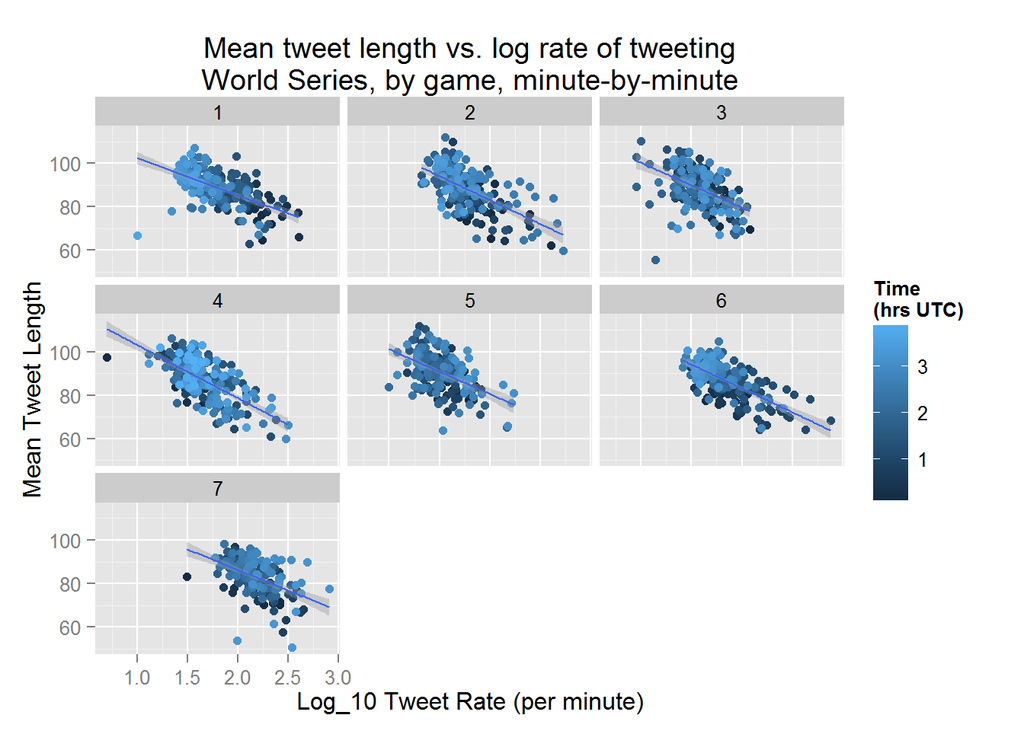

```
##
## Call:
## lm(formula = len ~ log10(rate), data = ms2)
##
## Residuals:
##    Min     1Q Median     3Q    Max
## -41.96  -4.21   0.53   5.17  21.15
##
## Coefficients:
##             Estimate Std. Error t value Pr(>|t|)
## (Intercept)   116.08       1.15   101.2   <2e-16 ***
## log10(rate)   -16.24       0.64   -25.4   <2e-16 ***
## ---
## Signif. codes:  0 '***' 0.001 '**' 0.01 '*' 0.05 '.' 0.1 ' ' 1
##
## Residual standard error: 7.37 on 1418 degrees of freedom
## Multiple R-squared:  0.312,  Adjusted R-squared:  0.312
## F-statistic:  644 on 1 and 1418 DF,  p-value: <2e-16
```

Some notes on these results:

1. We’re seeing a really robust negative relationship, across all games, between rate and length.
2. Different games have different interest profiles. Note that in Games 1 and 6, tweet rate drops steadily as time goes on; these games were both blowouts (7-1 and 10-0). In Game 7, on the other hand, tweet rate rises as time passes; this was a game decided in the final at-bat.

That’s based on the simple linear regression; let’s look at mixed-effects linear regression with by-game random intercepts and log(rate) slopes. (lrate is log(rate)):

```r
library(lme4)
ms2$gamef <- as.factor(ms2$gamenum)
ms2$lrate <- log10(ms2$rate)
summary(lmer(len ~ lrate + starttime + (1+lrate+starttime|gamef), data=ms2))
```

```
## Linear mixed model fit by REML ['lmerMod']
## Formula: len ~ lrate + starttime + (1 + lrate + starttime | gamef)
##    Data: ms2
##
## REML criterion at convergence: 9568
##
## Scaled residuals:
##    Min     1Q Median     3Q    Max
## -6.021 -0.575  0.043  0.643  2.995
##
## Random effects:
##  Groups   Name        Variance Std.Dev. Corr
##  gamef    (Intercept)  8.73    2.95
##           lrate        6.70    2.59     -0.99
##           starttime    1.06    1.03     -0.32  0.19
##  Residual             48.48    6.96
## Number of obs: 1420, groups:  gamef, 7
##
## Fixed effects:
##             Estimate Std. Error t value
## (Intercept)  120.670      1.817    66.4
## lrate        -20.065      1.248   -16.1
## starttime      1.050      0.435     2.4
##
## Correlation of Fixed Effects:
##           (Intr) lrate
## lrate     -0.947
## starttime -0.298  0.161
```

Also, since the random log(rate)/time intercepts are so tighty correlated, a version with standardized len & log(rate):

```r
ms3 <- ms2
ms3$lrate <- scale(ms2$lrate)
ms3$len <- scale(ms2$len)
ms3$starttime <- scale(ms2$starttime,scale=F)
summary(lmer(len ~ lrate + starttime + (1+lrate+starttime|gamef), data=ms3))
```

```
## Linear mixed model fit by REML ['lmerMod']
## Formula: len ~ lrate + starttime + (1 + lrate + starttime | gamef)
##    Data: ms3
##
## REML criterion at convergence: 3380
##
## Scaled residuals:
##    Min     1Q Median     3Q    Max
## -6.021 -0.575  0.043  0.643  2.995
##
## Random effects:
##  Groups   Name        Variance Std.Dev. Corr
##  gamef    (Intercept) 0.07740  0.278
##           lrate       0.00793  0.089    0.81
##           starttime   0.01345  0.116    0.73 0.19
##  Residual             0.61439  0.784
## Number of obs: 1420, groups:  gamef, 7
##
## Fixed effects:
##             Estimate Std. Error t value
## (Intercept)  -0.0254     0.1075   -0.24
## lrate        -0.6901     0.0429  -16.08
## starttime     0.1182     0.0489    2.41
##
## Correlation of Fixed Effects:
##           (Intr) lrate
## lrate     0.640
## starttime 0.641  0.161
```

### At-bat-by-at-bat analysis

We’re getting the start times for each at-bat from the MLBAM data. Re-grouping the data by at-bats instead of by minute:

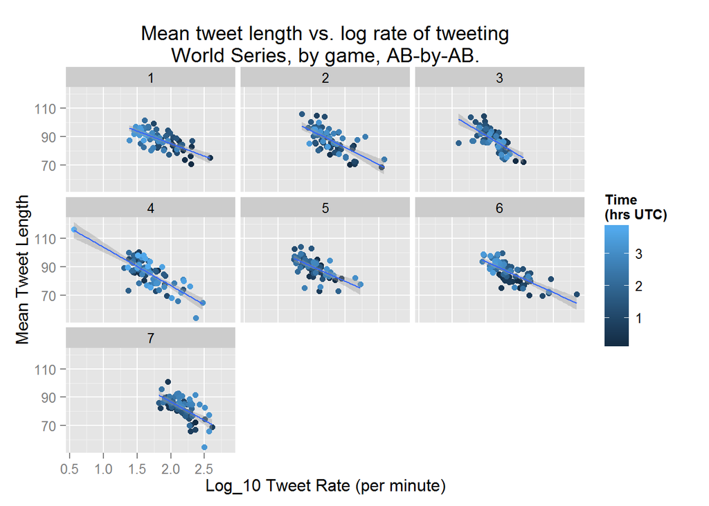

```r
msab <- ddply(tdf3, .(atbatnum,gamenum), summarise,
      len = mean(tsize),
      rate = length(tsize)/(mean(atbatlength)*60),
      o = mean(o),
      starttime = min(time))
qplot(log10(rate),len,data=msab,color=starttime) + facet_wrap(~gamenum) + geom_smooth(method='lm') + labs(title='Mean tweet length vs. log rate of tweeting\nWorld Series, by game, AB-by-AB.',y='Mean Tweet Length',x='Log_10 Tweet Rate (per minute)',color='Time\n(hrs UTC)')
```

```r
summary(lm(len ~ log(rate), data=msab))
```

```
##
## Call:
## lm(formula = len ~ log(rate), data = msab)
##
## Residuals:
##     Min      1Q  Median      3Q     Max
## -22.073  -3.916   0.439   4.251  17.546
##
## Coefficients:
##             Estimate Std. Error t value Pr(>|t|)
## (Intercept)  118.203      1.631    72.5   <2e-16 ***
## log(rate)     -7.692      0.394   -19.5   <2e-16 ***
## ---
## Signif. codes:  0 '***' 0.001 '**' 0.01 '*' 0.05 '.' 0.1 ' ' 1
##
## Residual standard error: 6.03 on 501 degrees of freedom
## Multiple R-squared:  0.432,  Adjusted R-squared:  0.431
## F-statistic:  381 on 1 and 501 DF,  p-value: <2e-16
```

```r
summary(lm(len ~ log(rate), data=filter(msab,o<3)))
```

```
##
## Call:
## lm(formula = len ~ log(rate), data = filter(msab, o < 3))
##
## Residuals:
##     Min      1Q  Median      3Q     Max
## -21.084  -4.422   0.556   4.327  18.201
##
## Coefficients:
##             Estimate Std. Error t value Pr(>|t|)
## (Intercept)  120.496      1.902    63.4   <2e-16 ***
## log(rate)     -8.346      0.461   -18.1   <2e-16 ***
## ---
## Signif. codes:  0 '***' 0.001 '**' 0.01 '*' 0.05 '.' 0.1 ' ' 1
##
## Residual standard error: 6.4 on 386 degrees of freedom
## Multiple R-squared:  0.459,  Adjusted R-squared:  0.458
## F-statistic:  327 on 1 and 386 DF,  p-value: <2e-16
```

(Two models here; the first includes all ABs, the second removes those that resulted in the third out since those trigger commercial breaks and 3 minute of inaction before the next AB starts. I didn’t find an effect of removing third-out ABs in any analysis except for reducing our statistical power, so I left them in in most of the analyses.)

Mixed-effects linear regression with by-game random intercepts and log(rate) and AB time slopes. Due to correlation of ranodm effects, I’m centering and scaling log-rate & length to avoid convergence problems.

```r
msab$gamef <- as.factor(msab$gamenum)
msab$lrate <- log10(msab$rate)
msab$lrate <- scale(msab$lrate)
msab$len <- scale(msab$len)
summary(lmer(len ~ lrate + starttime + (1+lrate+starttime|gamef), data=msab))
```

```
## Linear mixed model fit by REML ['lmerMod']
## Formula: len ~ lrate + starttime + (1 + lrate + starttime | gamef)
##    Data: msab
##
## REML criterion at convergence: 1075
##
## Scaled residuals:
##    Min     1Q Median     3Q    Max
## -4.422 -0.560  0.035  0.624  3.172
##
## Random effects:
##  Groups   Name        Variance Std.Dev. Corr
##  gamef    (Intercept) 0.0458   0.214
##           lrate       0.0179   0.134    0.75
##           starttime   0.0182   0.135    0.39 0.34
##  Residual             0.4600   0.678
## Number of obs: 503, groups:  gamef, 7
##
## Fixed effects:
##             Estimate Std. Error t value
## (Intercept)  -0.1997     0.1053   -1.90
## lrate        -0.8311     0.0644  -12.90
## starttime     0.0974     0.0602    1.62
##
## Correlation of Fixed Effects:
##           (Intr) lrate
## lrate      0.428
## starttime -0.033  0.270
```

**AB-by-AB summary:** Great, all the same stuff as before. I also ran a mixed-effects model with final ABs (of a half inning, those that get the third out) removed, since those extend into commercial breaks. The results were virtually identical, surprisingly and happily. The positive relationship between time and tweet length has persisted, though it’s no probably longer significant due to reduced data. I’m curious to see what happens to it once we move to LI.

### Leverage Index analysis

So far, we’ve been using tweet rate as a proxy for common ground, but we want to replace that for a few reasons. First, we’d rather not have the metrics so tied to Twitter. Second, it could be that people are simply dividing the same amount of linguistic information differently when they’re tweeting more, sending what would have been one tweet as two to maximize the likelihood of at least one being noticed when people are tweeting like crazy.

Our first non-Twitter proxy for common ground is Leverage Index, which estimates the importance of an at-bat on the win probabilities of the game. This is based entirely on the state of affairs at the start of the at-bat, as opposed to our later proxies that cover the result of the AB. Leverage Index here is taken from Fangraphs.com’s calculations.

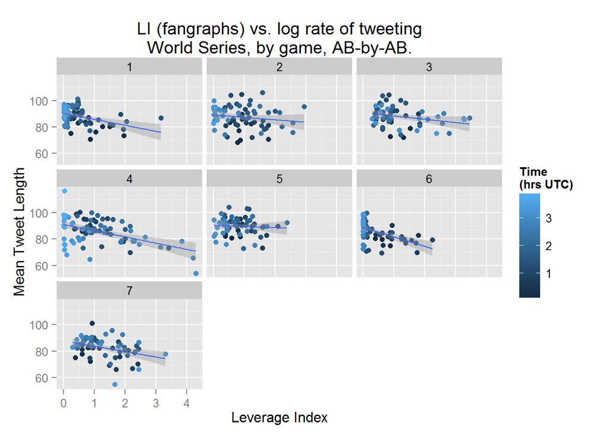

```r
fms <- ddply(fdf2, .(atbatnum,gamenum), summarise,
      len = mean(tsize),
      rate = length(tsize)/(mean(atbatlength)*60),
      starttime = min(time),
      o = mean(o),
      li.fg = mean(li.fg),
      li.book = mean(li.book))

qplot(li.fg,len,data=fms,color=starttime) + facet_wrap(~gamenum) + geom_smooth(method='lm') + labs(title='LI (fangraphs) vs. log rate of tweeting\nWorld Series, by game, AB-by-AB.',y='Mean Tweet Length',x='Leverage Index',color='Time\n(hrs UTC)')
```

```r
summary(lm(len ~ log10(rate) + li.fg + starttime,data=fms))
```

```
##
## Call:
## lm(formula = len ~ log10(rate) + li.fg + starttime, data = fms)
##
## Residuals:
##     Min      1Q  Median      3Q     Max
## -25.050  -3.745   0.366   4.641  15.675
##
## Coefficients:
##             Estimate Std. Error t value Pr(>|t|)
## (Intercept)  110.621      2.095   52.79  < 2e-16 ***
## log10(rate)   -9.482      0.839  -11.30  < 2e-16 ***
## li.fg         -3.105      0.394   -7.87  2.2e-14 ***
## starttime      0.289      0.303    0.95     0.34
## ---
## Signif. codes:  0 '***' 0.001 '**' 0.01 '*' 0.05 '.' 0.1 ' ' 1
##
## Residual standard error: 6.68 on 499 degrees of freedom
## Multiple R-squared:  0.306,  Adjusted R-squared:  0.302
## F-statistic: 73.5 on 3 and 499 DF,  p-value: <2e-16
```

```r
#summary(lm(len ~ log10(rate) + li.book + starttime,data=fms))
summary(lm(len ~ log10(rate) + li.fg + starttime,data=filter(fms,o<3)))
```

```
##
## Call:
## lm(formula = len ~ log10(rate) + li.fg + starttime, data = filter(fms,
##     o < 3))
##
## Residuals:
##     Min      1Q  Median      3Q     Max
## -23.870  -4.490   0.605   5.069  15.419
##
## Coefficients:
##             Estimate Std. Error t value Pr(>|t|)
## (Intercept) 114.3374     2.6164   43.70  < 2e-16 ***
## log10(rate) -10.8937     1.0437  -10.44  < 2e-16 ***
## li.fg        -3.2589     0.4673   -6.97  1.4e-11 ***
## starttime     0.0794     0.3694    0.22     0.83
## ---
## Signif. codes:  0 '***' 0.001 '**' 0.01 '*' 0.05 '.' 0.1 ' ' 1
##
## Residual standard error: 7.21 on 384 degrees of freedom
## Multiple R-squared:  0.317,  Adjusted R-squared:  0.311
## F-statistic: 59.3 on 3 and 384 DF,  p-value: <2e-16
```

```r
#summary(lm(len ~ log10(rate) + li.book + starttime,data=filter(fms,o<3)))
```

This shows the predicted negative effect of LI on length; more important ABs trigger shorter tweets. (This effect also appears with LI values taken from “The Book”, which was the original source for Leverage Index, even though those values are based on 2002.)

Moving to a mixed-effect model:

```r
fms2 <- fms
fms2$gamef <- as.factor(fms$gamenum)
fms2$lrate <- scale(log10(fms2$rate))
fms2$li <- scale(fms2$li.fg)
fms2$len <- scale(fms2$len)
summary(lmer(len ~ lrate + li + starttime + (1+lrate+li|gamef),data=fms2))
```

```
## Linear mixed model fit by REML ['lmerMod']
## Formula: len ~ lrate + li + starttime + (1 + lrate + li | gamef)
##    Data: fms2
##
## REML criterion at convergence: 1256
##
## Scaled residuals:
##    Min     1Q Median     3Q    Max
## -3.918 -0.517  0.065  0.710  2.309
##
## Random effects:
##  Groups   Name        Variance Std.Dev. Corr
##  gamef    (Intercept) 0.01711  0.1308
##           lrate       0.00551  0.0742   0.36
##           li          0.00435  0.0660   0.95 0.04
##  Residual             0.67832  0.8236
## Number of obs: 503, groups:  gamef, 7
##
## Fixed effects:
##             Estimate Std. Error t value
## (Intercept)  -0.0849     0.0936   -0.91
## lrate        -0.4250     0.0498   -8.54
## li           -0.3010     0.0489   -6.15
## starttime     0.0430     0.0387    1.11
##
## Correlation of Fixed Effects:
##           (Intr) lrate  li
## lrate      0.057
## li         0.107 -0.037
## starttime -0.740  0.081  0.237
```

I didn’t include starttime as a random slope because it impedes convergence and wasn’t significant above. (Though the estimates and t-values are similar in the under-converged full model and the converged smaller model.)

**LI summary:** There is again a robust negative correlation of LI on tweet length, even with the effect of tweet rate partialed out. More important ABs trigger shorter tweets.

### An aside about lag

One concern here is that the at-bat boundaries don’t quite match up with when people are tweeting about them. The end of an AB is triggered by the start of the next AB, so that includes some lag time, but it’s not obvious that there is enough for people to actually tweet before the next AB. This section performs some simple tests to examine appropriate lag times, though it’s not obvious that we actually can or should correct for it.

Our first test is the simplest. Assuming that LI and tweet rate are correlated – since people should tweet more at more interesting points in the game – let’s just look at AB-by-AB correlations between LI and log-rate with different offsets. Throughout this section, positive offsets mean we think that tweets are later than their triggering event. So an offset of +30 seconds would mean that tweets appear 30 seconds after the event they’re referring to. Negative offsets mean that tweets precede their events, which seems crazy unless the MLBAM at-bat times are poorly calibrated.

To avoid pre- and post-game tweets, we’ll only look at at-bats in hours 1-3 of the games (the shortest game ends about 15 minutes after this).

```
## [1] -30
## [1] -25
## [1] -20
## [1] -15
## [1] -10
## [1] -5
## [1] 0
## [1] 5
## [1] 10
## [1] 15
## [1] 20
## [1] 25
## [1] 30
## [1] 35
## [1] 40
```

[output cut: 16 more lines]

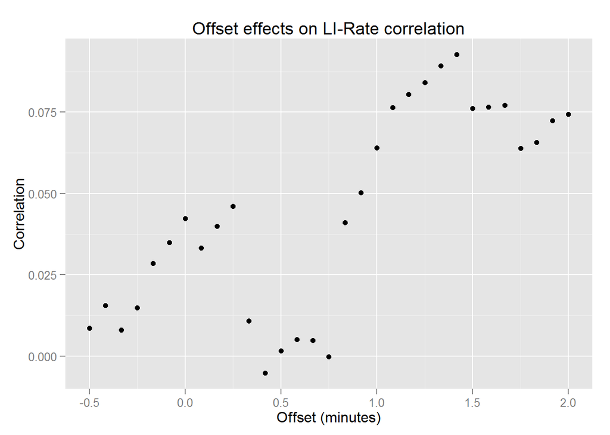

As it turns out, the correlations are way too small to be confident in this as a metric. So here’s a different approach. Let’s try fitting models of length by rate and LI, and seeing how log-likelihood of the model varies with offset.

```r
atbats <- unique(data.frame(gamenum=bbdf$gamenum,atbattime=bbdf$atbattime,atbatnum=bbdf$atbatnum,o=bbdf$o))
atbats$atbatlength <- 0
offsets <- seq(-30/3600,120/3600,5/3600)
tdf2 <- filter(tdf,(time>1)&(time<3))
tdf2$truetime <- tdf2$time
lmodels <- list()
lls <- vector()
for (i in 1:length(offsets)) {
  offset <- offsets[i]
  print(offset*3600)
  tdf2$time <- tdf2$truetime-offset
  tdf2$atbatnum <- 0
  for (gamenum in 1:7) {
    tdf2$atbatnum[tdf2$gamenum==gamenum] <- cut(tdf2$time[tdf2$gamenum==gamenum],breaks=atbats$atbattime[atbats$gamenum==gamenum],labels=FALSE)
    atbats$atbatlength[atbats$gamenum==gamenum] <- c(diff(atbats$atbattime[atbats$gamenum==gamenum]),NA)
    }
  tdf2 <- filter(tdf2,!is.na(atbatnum))
  tempab <- data.frame(gamenum=atbats$gamenum,atbatnum=atbats$atbatnum,atbatlength=atbats$atbatlength,o=atbats$o)
  tdf3 <- merge(tdf2,tempab,by=c('gamenum','atbatnum'))
  tdf3 <- filter(tdf3,!is.na(atbatlength))

  fdffg <- merge(tdf3,fgdfsm,by=c('atbatnum','gamenum'))
  fms <- ddply(filter(fdffg,o<3), .(atbatnum,gamenum), summarise,
      len = mean(tsize),
      rate = length(tsize)/(mean(atbatlength)*60),
      starttime = min(time),
      li = mean(li.fg))
  fms$gamef <- as.factor(fms$gamenum)
  fms$lrate <- log10(fms$rate)
  fms$lrate <- scale(fms$lrate)
  fms$len <- scale(fms$len)
  fms$li <- scale(fms$li)
  lmodel <- lmer(len ~ lrate + li + (1+lrate+li|gamef),data=fms)
  lmodels[i] <- lmodel
  lls[i] <- logLik(lmodel)[1]
}
```

```
## [1] -30
## [1] -25
## [1] -20
## [1] -15
## [1] -10
## [1] -5
## [1] 0
## [1] 5
## [1] 10
## [1] 15
## [1] 20
## [1] 25
## [1] 30
```

```
## [1] 35
## [1] 40
## [1] 45
## [1] 50
## [1] 55
```

```
## [1] 60
## [1] 65
```

```
## [1] 70
## [1] 75
## [1] 80
## [1] 85
## [1] 90
## [1] 95
## [1] 100
## [1] 105
```

```
## [1] 110
```

```
## [1] 115
```

```
## [1] 120
```

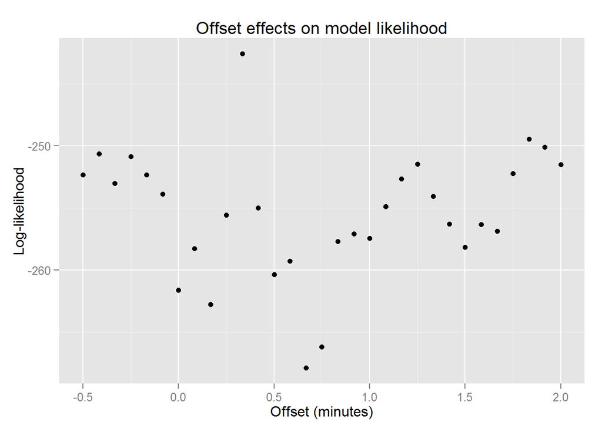

```r
qplot(offsets*60,lls) + labs(title='Offset effects on model likelihood',y='Log-likelihood',x='Offset (minutes)')
```

Aside from the high-likelihood outlier with the 20 seconds offset, the likelihoods don’t have a clear pattern. I’m not going to add an offset since neither method offers a clearly appropriate offset.

### Run expectancy

We added Leverage Index as a proxy for common ground. LI is a bit of a conflated measure, though, as the importance of an AB depends both on how many referents are available for the common ground (things like runners on base, recent good plays) and how much attention people are likely to be paying (availability of those items in common ground). Let’s try run expectancy, which depends only on how many players are on base and how many outs there are, serving as a proxy for available referents independent of how interesting the rest of the game is (as RE is the same regardless of the score and which inning it is).

[figure not shown]

```r
summary(lm(len ~ log10(rate) + re.fg + starttime,data=fms))
```

```
##
## Call:
## lm(formula = len ~ log10(rate) + re.fg + starttime, data = fms)
##
## Residuals:
##    Min     1Q Median     3Q    Max
## -3.940 -0.457  0.044  0.575  2.170
##
## Coefficients:
##             Estimate Std. Error t value Pr(>|t|)
## (Intercept)   2.4563     0.2672    9.19  < 2e-16 ***
## log10(rate)  -1.1482     0.1082  -10.61  < 2e-16 ***
## re.fg        -0.2351     0.0386   -6.09  2.2e-09 ***
## starttime     0.0935     0.0379    2.46    0.014 *
## ---
## Signif. codes:  0 '***' 0.001 '**' 0.01 '*' 0.05 '.' 0.1 ' ' 1
##
## Residual standard error: 0.854 on 499 degrees of freedom
## Multiple R-squared:  0.274,  Adjusted R-squared:  0.27
## F-statistic: 62.8 on 3 and 499 DF,  p-value: <2e-16
```

```r
#summary(lm(len ~ log10(rate) + li.book + starttime,data=fms))
summary(lm(len ~ log10(rate) + li.fg + re.fg + starttime,data=fms))
```

```
##
## Call:
## lm(formula = len ~ log10(rate) + li.fg + re.fg + starttime, data = fms)
##
## Residuals:
##    Min     1Q Median     3Q    Max
## -3.358 -0.476  0.066  0.552  2.032
##
## Coefficients:
##             Estimate Std. Error t value Pr(>|t|)
## (Intercept)   2.5366     0.2596    9.77  < 2e-16 ***
## log10(rate)  -1.1454     0.1050  -10.91  < 2e-16 ***
## li.fg        -0.2432     0.0427   -5.69  2.2e-08 ***
## re.fg        -0.1254     0.0421   -2.98    0.003 **
## starttime     0.0456     0.0378    1.21    0.228
## ---
## Signif. codes:  0 '***' 0.001 '**' 0.01 '*' 0.05 '.' 0.1 ' ' 1
##
## Residual standard error: 0.829 on 498 degrees of freedom
## Multiple R-squared:  0.318,  Adjusted R-squared:  0.313
## F-statistic: 58.2 on 4 and 498 DF,  p-value: <2e-16
```

```r
#summary(lm(len ~ log10(rate) + li.book + starttime,data=filter(fms,o<3)))
summary(lmer(len ~ lrate + li.fg + re.fg + starttime + (1+lrate+li.fg+re.fg|gamef),data=fms))
```

```
## Linear mixed model fit by REML ['lmerMod']
## Formula: len ~ lrate + li.fg + re.fg + starttime + (1 + lrate + li.fg +
##     re.fg | gamef)
##    Data: fms
##
## REML criterion at convergence: 1251
##
## Scaled residuals:
##    Min     1Q Median     3Q    Max
## -4.187 -0.559  0.088  0.698  2.421
##
## Random effects:
##  Groups   Name        Variance Std.Dev. Corr
##  gamef    (Intercept) 0.01074  0.1036
##           lrate       0.00248  0.0498   0.50
##           li.fg       0.00123  0.0350   0.97 0.27
##           re.fg       0.00405  0.0636   0.97 0.28 1.00
##  Residual             0.66939  0.8182
## Number of obs: 503, groups:  gamef, 7
##
## Fixed effects:
##             Estimate Std. Error t value
## (Intercept)  -0.1073     0.0879   -1.22
## lrate        -0.4112     0.0436   -9.43
## li.fg        -0.2248     0.0490   -4.58
## re.fg        -0.1174     0.0502   -2.34
## starttime     0.0625     0.0385    1.62
##
## Correlation of Fixed Effects:
##           (Intr) lrate  li.fg  re.fg
## lrate      0.047
## li.fg     -0.087  0.019
## re.fg      0.288 -0.011 -0.303
## starttime -0.787  0.084  0.276 -0.108
```

```r
cor(fms$li.fg,fms$re.fg)
```

```
##        [,1]
## [1,] 0.4596
```

These models show that RE, like LI, has a significant negative effect on tweet length. Their random effects are tightly correlated, so they’re seeming to provide explanations of similar effects. They’re pretty correlated overall as well (~0.5). Still, we’re seeing both proxies for common ground having a significant effect on length.

### Pre- vs. Post-AB effects

Both LI and RE are proxies for what is happening at the start of the at-bat. Fangraphs also provides some proxies for what happens as a result of the at-bat. The first is Win Probability Added, the amount that the win expectancy changes as a result of the at-bat. The second is RE24, which is the change in run expectancy as a result of the at-bat. WPA is like LI in that it captures both how much happened and how much attention would be paid to it. RE24 is like RE in that it capture how much happened independent of whether it was an important or unimportant part of the game.

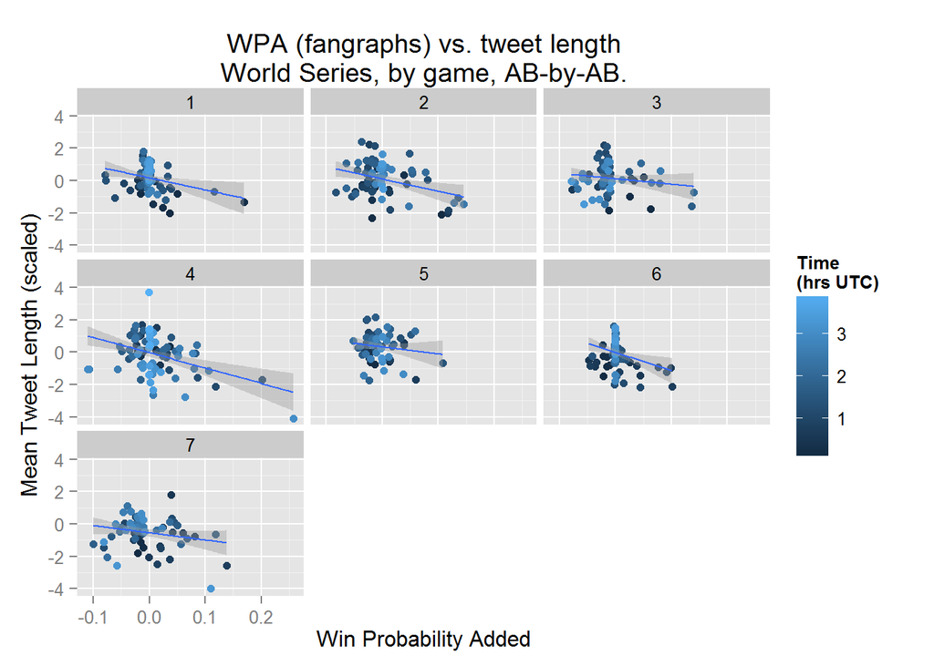

```r
qplot(wpa,len,data=fms,color=starttime) + facet_wrap(~gamenum) + geom_smooth(method='lm') + labs(title='WPA (fangraphs) vs. tweet length\nWorld Series, by game, AB-by-AB.',y='Mean Tweet Length (scaled)',x='Win Probability Added',color='Time\n(hrs UTC)')
```

[figure not shown]

```r
qplot(re24,len,data=fms,color=starttime) + facet_wrap(~gamenum) + geom_smooth(method='lm') + labs(title='RE24 (fangraphs) vs. tweet length\nWorld Series, by game, AB-by-AB.',y='Mean Tweet Length (scaled)',x='Run Expectancy Change',color='Time\n(hrs UTC)')
```

```r
fms$wpa <- scale(fms$wpa)
fms$re24 <- scale(fms$re24)


summary(lm(len ~ log10(rate) + li.fg + wpa + starttime,data=fms))
```

```
##
## Call:
## lm(formula = len ~ log10(rate) + li.fg + wpa + starttime, data = fms)
##
## Residuals:
##     Min      1Q  Median      3Q     Max
## -2.5722 -0.4515  0.0546  0.5613  2.0763
##
## Coefficients:
##             Estimate Std. Error t value Pr(>|t|)
## (Intercept)   2.5255     0.2498   10.11  < 2e-16 ***
## log10(rate)  -1.1243     0.1014  -11.09  < 2e-16 ***
## li.fg        -0.2991     0.0368   -8.12  3.7e-15 ***
## wpa          -0.2323     0.0361   -6.44  2.9e-10 ***
## starttime     0.0252     0.0365    0.69     0.49
## ---
## Signif. codes:  0 '***' 0.001 '**' 0.01 '*' 0.05 '.' 0.1 ' ' 1
##
## Residual standard error: 0.803 on 498 degrees of freedom
## Multiple R-squared:  0.36,   Adjusted R-squared:  0.354
## F-statistic: 69.9 on 4 and 498 DF,  p-value: <2e-16
```

```r
#summary(lm(len ~ log10(rate) + li.book + starttime,data=fms))
summary(lm(len ~ log10(rate) + re.fg + re24 + starttime,data=fms))
```

```
##
## Call:
## lm(formula = len ~ log10(rate) + re.fg + re24 + starttime, data = fms)
##
## Residuals:
##    Min     1Q Median     3Q    Max
## -3.694 -0.470  0.013  0.558  2.192
##
## Coefficients:
##             Estimate Std. Error t value Pr(>|t|)
## (Intercept)   2.2102     0.2598    8.51  < 2e-16 ***
## log10(rate)  -1.0369     0.1055   -9.83  < 2e-16 ***
## re.fg        -0.2141     0.0372   -5.75  1.6e-08 ***
## re24         -0.2414     0.0374   -6.45  2.7e-10 ***
## starttime     0.0887     0.0365    2.43    0.015 *
## ---
## Signif. codes:  0 '***' 0.001 '**' 0.01 '*' 0.05 '.' 0.1 ' ' 1
##
## Residual standard error: 0.822 on 498 degrees of freedom
## Multiple R-squared:  0.33,   Adjusted R-squared:  0.325
## F-statistic: 61.4 on 4 and 498 DF,  p-value: <2e-16
```

```r
#summary(lm(len ~ log10(rate) + li.book + starttime,data=filter(fms,o<3)))
```

```r
summary(lmer(len ~ lrate + li.fg + wpa + starttime + (1+lrate+li.fg+wpa|gamef),data=fms))
```

```
## Linear mixed model fit by REML ['lmerMod']
## Formula: len ~ lrate + li.fg + wpa + starttime + (1 + lrate + li.fg +
##     wpa | gamef)
##    Data: fms
##
## REML criterion at convergence: 1225
##
## Scaled residuals:
##    Min     1Q Median     3Q    Max
## -3.231 -0.548  0.059  0.697  2.577
##
## Random effects:
##  Groups   Name        Variance Std.Dev. Corr
##  gamef    (Intercept) 8.00e-03 0.08947
##           lrate       3.00e-03 0.05477   0.10
##           li.fg       1.54e-03 0.03918   0.64 -0.70
##           wpa         6.11e-05 0.00782   0.91  0.50  0.26
##  Residual             6.36e-01 0.79764
## Number of obs: 503, groups:  gamef, 7
##
## Fixed effects:
##             Estimate Std. Error t value
## (Intercept)  -0.0595     0.0835   -0.71
## lrate        -0.4016     0.0440   -9.12
## li.fg        -0.3015     0.0419   -7.20
## wpa          -0.2251     0.0366   -6.16
## starttime     0.0308     0.0370    0.83
##
## Correlation of Fixed Effects:
##           (Intr) lrate  li.fg  wpa
## lrate     -0.046
## li.fg     -0.073 -0.177
## wpa       -0.013 -0.078  0.007
## starttime -0.800  0.087  0.226  0.055
```

```r
summary(lmer(len ~ lrate + re.fg + re24 + starttime + (1+lrate+re.fg+re24|gamef),data=fms))
```

```
## Linear mixed model fit by REML ['lmerMod']
## Formula: len ~ lrate + re.fg + re24 + starttime + (1 + lrate + re.fg +
##     re24 | gamef)
##    Data: fms
##
## REML criterion at convergence: 1236
##
## Scaled residuals:
##    Min     1Q Median     3Q    Max
## -4.548 -0.568  0.036  0.700  2.657
##
## Random effects:
##  Groups   Name        Variance Std.Dev. Corr
##  gamef    (Intercept) 0.01492  0.1222
##           lrate       0.00218  0.0467   1.00
##           re.fg       0.00701  0.0838   1.00 1.00
##           re24        0.00263  0.0513   1.00 1.00 1.00
##  Residual             0.64731  0.8046
## Number of obs: 503, groups:  gamef, 7
##
## Fixed effects:
##             Estimate Std. Error t value
## (Intercept)  -0.1900     0.0883   -2.15
## lrate        -0.3771     0.0428   -8.81
## re.fg        -0.2112     0.0490   -4.32
## re24         -0.2303     0.0422   -5.46
## starttime     0.1083     0.0363    2.98
##
## Correlation of Fixed Effects:
##           (Intr) lrate  re.fg  re24
## lrate      0.179
## re.fg      0.333  0.205
## re24       0.215  0.053  0.254
## starttime -0.744  0.076  0.023  0.040
```

Both the LI/WPA pairing and the RE/RE24 pairing show significant negative effects on tweet length. Both the situation at the start of the AB and the result of the AB influence how people tweet.

## Alternative metrics of linguistic information

Now let’s consider alternative metrics of linguistic information besides tweet length, such as entropy. Entropy calculations are performed game-by-game, with the training corpus for one game being all the other games’ tweets. All entropy values are per-word.

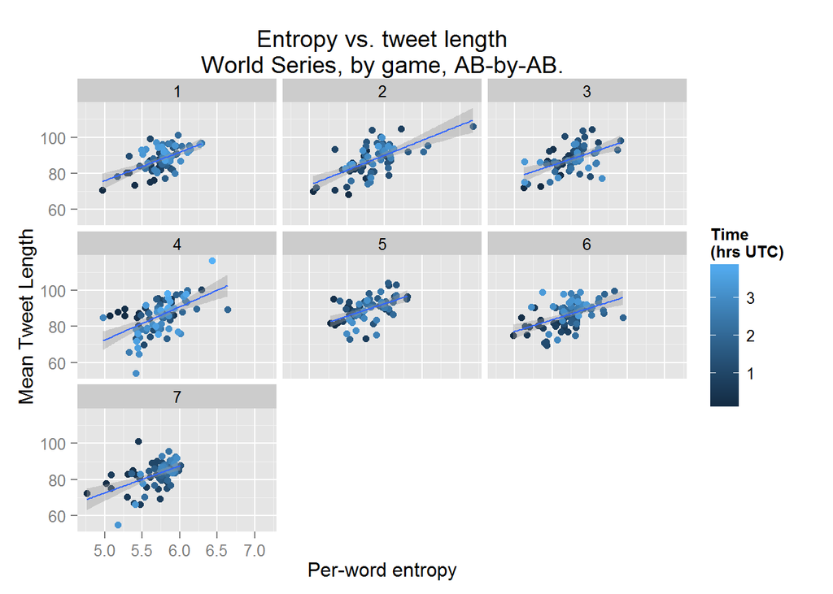

```r
fms <- ddply(fdf2, .(atbatnum,gamenum), summarise,
      len = mean(tsize),
      ent = mean(entropy),
      rate = length(tsize)/(mean(atbatlength)*60),
      starttime = min(time),
      o = mean(o),
      li.fg = mean(li.fg),
      #li.book = mean(li.book),
      wpa = mean(wpa),
      re.fg = mean(re.fg),
      re24 = mean(re24))

qplot(ent,len,data=fms,color=starttime) + facet_wrap(~gamenum) + geom_smooth(method='lm') + labs(title='Entropy vs. tweet length\nWorld Series, by game, AB-by-AB.',y='Mean Tweet Length',x='Per-word entropy',color='Time\n(hrs UTC)')
```

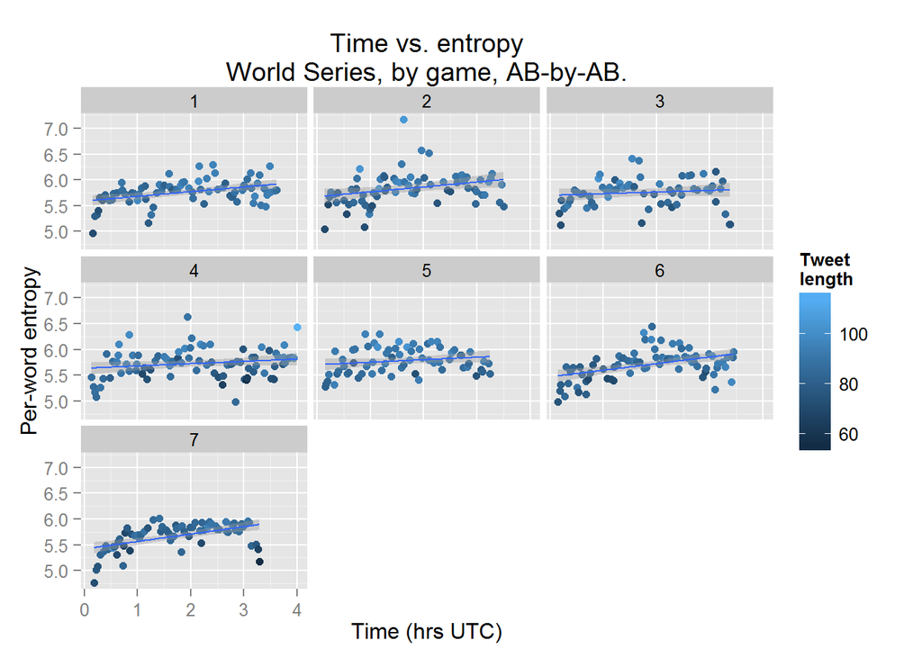

```r
qplot(starttime,ent,data=fms,color=len) + facet_wrap(~gamenum) + geom_smooth(method='lm') + labs(title='Time vs. entropy\nWorld Series, by game, AB-by-AB.',y='Per-word entropy',x='Time (hrs UTC)',color='Tweet\nlength')
```

```r
summary(lm(ent ~ log10(rate) + li.fg + wpa + starttime,data=fms))
```

```
##
## Call:
## lm(formula = ent ~ log10(rate) + li.fg + wpa + starttime, data = fms)
##
## Residuals:
##    Min     1Q Median     3Q    Max
## -3.033 -0.594  0.040  0.573  4.641
##
## Coefficients:
##             Estimate Std. Error t value Pr(>|t|)
## (Intercept)   0.8025     0.2888    2.78   0.0057 **
## log10(rate)  -0.5375     0.1172   -4.59  5.7e-06 ***
## li.fg        -0.0619     0.0426   -1.45   0.1467
## wpa          -0.1319     0.0417   -3.16   0.0017 **
## starttime     0.2351     0.0422    5.57  4.2e-08 ***
## ---
## Signif. codes:  0 '***' 0.001 '**' 0.01 '*' 0.05 '.' 0.1 ' ' 1
##
## Residual standard error: 0.929 on 498 degrees of freedom
## Multiple R-squared:  0.144,  Adjusted R-squared:  0.137
## F-statistic:   21 on 4 and 498 DF,  p-value: 5.16e-16
```

```r
#summary(lm(len ~ log10(rate) + li.book + starttime,data=fms))
summary(lm(ent ~ log10(rate) + re.fg + re24 + starttime,data=fms))
```

```
##
## Call:
## lm(formula = ent ~ log10(rate) + re.fg + re24 + starttime, data = fms)
##
## Residuals:
##    Min     1Q Median     3Q    Max
## -3.149 -0.590  0.046  0.572  4.663
##
## Coefficients:
##             Estimate Std. Error t value Pr(>|t|)
## (Intercept)   0.6968     0.2942    2.37   0.0183 *
## log10(rate)  -0.5036     0.1195   -4.22  3.0e-05 ***
## re.fg        -0.0531     0.0422   -1.26   0.2083
## re24         -0.1190     0.0424   -2.81   0.0052 **
## starttime     0.2507     0.0413    6.06  2.6e-09 ***
## ---
## Signif. codes:  0 '***' 0.001 '**' 0.01 '*' 0.05 '.' 0.1 ' ' 1
##
## Residual standard error: 0.931 on 498 degrees of freedom
## Multiple R-squared:  0.141,  Adjusted R-squared:  0.134
## F-statistic: 20.4 on 4 and 498 DF,  p-value: 1.37e-15
```

```r
#summary(lm(len ~ log10(rate) + li.book + starttime,data=filter(fms,o<3)))
summary(lmer(ent ~ lrate + li.fg + wpa + starttime + (1+lrate+li.fg+wpa|gamef),data=fms))
```

```
## Linear mixed model fit by REML ['lmerMod']
## Formula: ent ~ lrate + li.fg + wpa + starttime + (1 + lrate + li.fg +
##     wpa | gamef)
##    Data: fms
##
## REML criterion at convergence: 1355
##
## Scaled residuals:
##    Min     1Q Median     3Q    Max
## -3.256 -0.626  0.086  0.605  4.084
##
## Random effects:
##  Groups   Name        Variance Std.Dev. Corr
##  gamef    (Intercept) 0.03124  0.1767
##           lrate       0.00507  0.0712   -0.94
##           li.fg       0.02594  0.1611    0.98 -0.99
##           wpa         0.00557  0.0747   -0.98  0.99 -1.00
##  Residual             0.81799  0.9044
## Number of obs: 503, groups:  gamef, 7
##
## Fixed effects:
##             Estimate Std. Error t value
## (Intercept)  -0.4741     0.1092   -4.34
## lrate        -0.1756     0.0523   -3.36
## li.fg        -0.0732     0.0767   -0.95
## wpa          -0.1206     0.0503   -2.40
## starttime     0.2494     0.0425    5.88
##
## Correlation of Fixed Effects:
##           (Intr) lrate  li.fg  wpa
## lrate     -0.380
## li.fg      0.392 -0.430
## wpa       -0.361  0.199 -0.478
## starttime -0.687  0.104  0.168  0.013
```

```r
summary(lmer(ent ~ lrate + re.fg + re24 + starttime + (1+lrate+re.fg+re24|gamef),data=fms))
```

```
## Linear mixed model fit by REML ['lmerMod']
## Formula: ent ~ lrate + re.fg + re24 + starttime + (1 + lrate + re.fg +
##     re24 | gamef)
##    Data: fms
##
## REML criterion at convergence: 1371
##
## Scaled residuals:
##    Min     1Q Median     3Q    Max
## -3.405 -0.639  0.057  0.617  4.817
##
## Random effects:
##  Groups   Name        Variance Std.Dev. Corr
##  gamef    (Intercept) 0.00000  0.0000
##           lrate       0.00316  0.0562     NaN
##           re.fg       0.00105  0.0324     NaN -1.00
##           re24        0.00469  0.0685     NaN  1.00 -1.00
##  Residual             0.85789  0.9262
## Number of obs: 503, groups:  gamef, 7
##
## Fixed effects:
##             Estimate Std. Error t value
## (Intercept)  -0.4676     0.0863   -5.42
## lrate        -0.1836     0.0479   -3.83
## re.fg        -0.0496     0.0439   -1.13
## re24         -0.1244     0.0503   -2.47
## starttime     0.2568     0.0414    6.20
##
## Correlation of Fixed Effects:
##           (Intr) lrate  re.fg  re24
## lrate     -0.080
## re.fg     -0.026 -0.241
## re24      -0.003  0.105 -0.214
## starttime -0.874  0.099  0.022  0.002
```

Looking at per-word entropy, we find a strong negative relationship with tweet rate, so tweets are more predictable when they are coming faster. There is also a strong positive relationship with time, matching up neatly with the Genzel and Charniak results. Tweets are less predictable as the game goes on.

Interestingly, unlike with tweet length, there is no significant effect of the pre-AB proxies for common ground (LI/RE). The post-AB proxies are significant, though, with ABs that have more of an impact on the game reducing entropy in both proxies (WPA/RE24). The mixed-effects models show teh same patterns but aren’t converging.

### Pronominalization

Lastly, let’s consider the use of pronouns as a proxy for linguistic information. Here we’ll use the percentage of tweets per AB that contain a third-person masculine pronoun (he/him/his) to get an idea of when people are referencing someone in common ground (women are very very rarely mentioned in these tweets).

As it turns out, pronominalization does not show much of a relationship to our other proxies for common ground. Only the post-AB proxies (WPA/RE24) are significant, and the significance is lost in the mixed-effect models.

```r
tdf4$he <- grepl('(?<![A-Z])(he|his|him)(?![A-Z])',tdf4$tweet,perl=T,ignore.case=T)
fdf2 <- merge(tdf4,fgdfsm,by=c('atbatnum','gamenum'))
fdf2 <- merge(fdf2,bbdf,by=c('atbatnum','gamenum'))
fdf2$li <- NULL
```

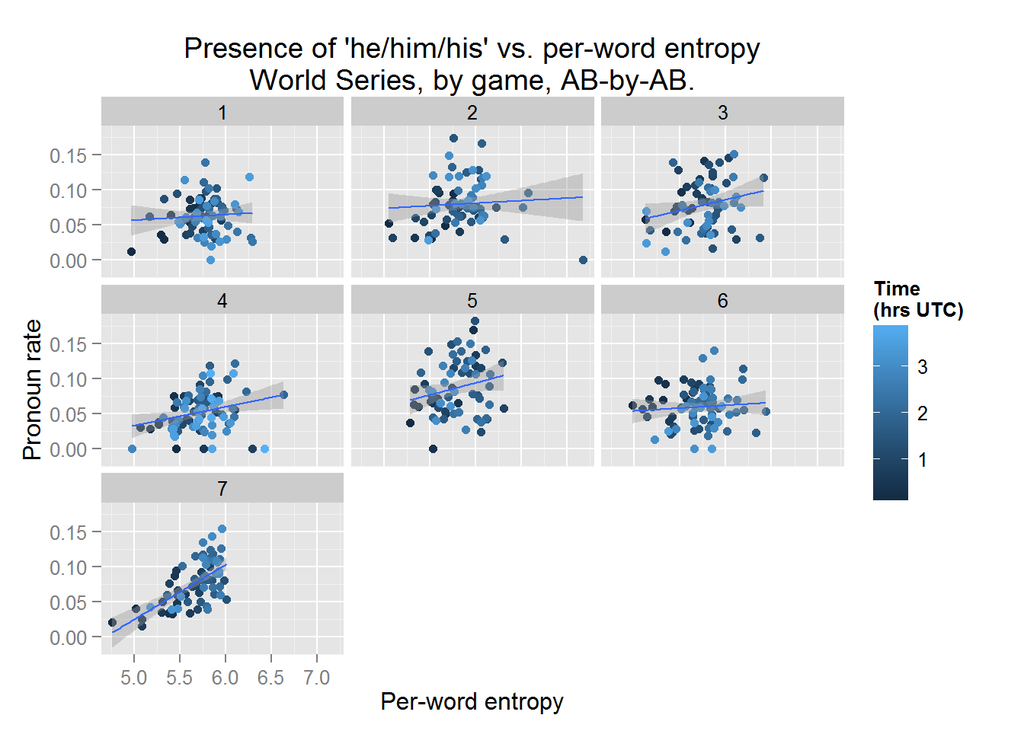

```r
fms <- ddply(fdf2, .(atbatnum,gamenum), summarise,
      len = mean(tsize),
      ent = mean(entropy),
      rate = length(tsize)/(mean(atbatlength)*60),
      starttime = min(time),
      o = mean(o),
      li.fg = mean(li.fg),
      he = mean(he),
      wpa = mean(wpa),
      re.fg = mean(re.fg),
      re24 = mean(re24))

qplot(ent,he,data=fms,color=starttime) + facet_wrap(~gamenum) + geom_smooth(method='lm') + labs(title='Presence of \'he/him/his\' vs. per-word entropy\nWorld Series, by game, AB-by-AB.',y='Pronoun rate',x='Per-word entropy',color='Time\n(hrs UTC)')
```

```r
fms$gamef <- as.factor(fms$gamenum)
fms$lrate <- log10(fms$rate)
fms$lrate <- scale(fms$lrate)
fms$len <- scale(fms$len)
fms$ent <- scale(fms$ent)
fms$li.fg <- scale(fms$li.fg)
fms$wpa <- scale(fms$wpa)
fms$re.fg <- scale(fms$re.fg)
fms$re24 <- scale(fms$re24)
fms$he <- scale(fms$he)
```

```r
summary(lm(he ~ lrate + li.fg + wpa + starttime,data=fms))
```

```
##
## Call:
## lm(formula = he ~ lrate + li.fg + wpa + starttime, data = fms)
##
## Residuals:
##    Min     1Q Median     3Q    Max
## -2.219 -0.705 -0.058  0.572  3.253
##
## Coefficients:
##             Estimate Std. Error t value Pr(>|t|)
## (Intercept)  0.01669    0.09340    0.18     0.86
## lrate        0.00573    0.04511    0.13     0.90
## li.fg        0.04817    0.04567    1.05     0.29
## wpa         -0.11537    0.04475   -2.58     0.01 *
## starttime   -0.00919    0.04527   -0.20     0.84
## ---
## Signif. codes:  0 '***' 0.001 '**' 0.01 '*' 0.05 '.' 0.1 ' ' 1
##
## Residual standard error: 0.996 on 498 degrees of freedom
## Multiple R-squared:  0.0154, Adjusted R-squared:  0.00751
## F-statistic: 1.95 on 4 and 498 DF,  p-value: 0.101
```

```r
#summary(lm(len ~ log10(rate) + li.book + starttime,data=fms))
summary(lm(he ~ lrate + re.fg + re24 + starttime,data=fms))
```

```
##
## Call:
## lm(formula = he ~ lrate + re.fg + re24 + starttime, data = fms)
##
## Residuals:
##    Min     1Q Median     3Q    Max
## -2.148 -0.723 -0.049  0.591  3.272
##
## Coefficients:
##             Estimate Std. Error t value Pr(>|t|)
## (Intercept)   0.0297     0.0920    0.32    0.747
## lrate         0.0216     0.0460    0.47    0.639
## re.fg        -0.0428     0.0452   -0.95    0.345
## re24         -0.0958     0.0455   -2.11    0.036 *
## starttime    -0.0164     0.0443   -0.37    0.712
## ---
## Signif. codes:  0 '***' 0.001 '**' 0.01 '*' 0.05 '.' 0.1 ' ' 1
##
## Residual standard error: 0.998 on 498 degrees of freedom
## Multiple R-squared:  0.0115, Adjusted R-squared:  0.00361
## F-statistic: 1.45 on 4 and 498 DF,  p-value: 0.215
```

```r
#summary(lm(len ~ log10(rate) + li.book + starttime,data=filter(fms,o<3)))
summary(lmer(he ~ lrate + li.fg + wpa + starttime + (1+lrate+li.fg+wpa|gamef),data=fms))
```

```
## Linear mixed model fit by REML ['lmerMod']
## Formula:
## he ~ lrate + li.fg + wpa + starttime + (1 + lrate + li.fg + wpa |
##     gamef)
##    Data: fms
##
## REML criterion at convergence: 1391
##
## Scaled residuals:
##     Min      1Q  Median      3Q     Max
## -2.7397 -0.7640 -0.0506  0.6632  3.0891
##
## Random effects:
##  Groups   Name        Variance Std.Dev. Corr
##  gamef    (Intercept) 0.13757  0.3709
##           lrate       0.00242  0.0492    0.42
##           li.fg       0.00975  0.0987   -0.84  0.14
##           wpa         0.00857  0.0926    0.92  0.74 -0.57
##  Residual             0.86719  0.9312
## Number of obs: 503, groups:  gamef, 7
##
## Fixed effects:
##             Estimate Std. Error t value
## (Intercept)  -0.0380     0.1662   -0.23
## lrate         0.0326     0.0509    0.64
## li.fg         0.0131     0.0598    0.22
## wpa          -0.0636     0.0559   -1.14
## starttime     0.0464     0.0438    1.06
##
## Correlation of Fixed Effects:
##           (Intr) lrate  li.fg  wpa
## lrate      0.093
## li.fg     -0.525 -0.020
## wpa        0.461  0.098 -0.195
## starttime -0.469  0.080  0.164  0.067
```

```r
summary(lmer(he ~ lrate + re.fg + re24 + starttime + (1+lrate+re.fg+re24|gamef),data=fms))
```

```
## Linear mixed model fit by REML ['lmerMod']
## Formula: he ~ lrate + re.fg + re24 + starttime + (1 + lrate + re.fg +
##     re24 | gamef)
##    Data: fms
##
## REML criterion at convergence: 1395
##
## Scaled residuals:
##     Min      1Q  Median      3Q     Max
## -2.6446 -0.7214 -0.0627  0.6661  3.0788
##
## Random effects:
##  Groups   Name        Variance Std.Dev. Corr
##  gamef    (Intercept) 1.40e-01 0.37383
##           lrate       1.64e-03 0.04051  0.30
##           re.fg       5.16e-05 0.00718  0.86 0.74
##           re24        8.46e-03 0.09198  0.67 0.91 0.95
##  Residual             8.74e-01 0.93502
## Number of obs: 503, groups:  gamef, 7
##
## Fixed effects:
##             Estimate Std. Error t value
## (Intercept) -0.04124    0.16625   -0.25
## lrate        0.04280    0.05192    0.82
## re.fg       -0.00523    0.04281   -0.12
## re24        -0.05273    0.05617   -0.94
## starttime    0.04053    0.04241    0.96
##
## Correlation of Fixed Effects:
##           (Intr) lrate  re.fg  re24
## lrate      0.027
## re.fg      0.032 -0.094
## re24       0.346  0.033 -0.016
## starttime -0.461  0.107  0.036  0.022
```